# Lesson 4 : Explore Two variables

```r
#pf <- read.csv("pseudo_facebook.tsv", sep = '\t')

pf <- read.delim("pseudo_facebook.tsv", stringsAsFactors = FALSE)
names(pf)
```

```
##  [1] "userid"                "age"
##  [3] "dob_day"               "dob_year"
##  [5] "dob_month"             "gender"
##  [7] "tenure"                "friend_count"
##  [9] "friendships_initiated" "likes"
## [11] "likes_received"        "mobile_likes"
## [13] "mobile_likes_received" "www_likes"
## [15] "www_likes_received"
```

```r
head(pf)
```

```
##    userid age dob_day dob_year dob_month gender tenure friend_count
## 1 2094382  14      19     1999        11   male    266            0
## 2 1192601  14       2     1999        11 female      6            0
## 3 2083884  14      16     1999        11   male     13            0
## 4 1203168  14      25     1999        12 female     93            0
## 5 1733186  14       4     1999        12   male     82            0
## 6 1524765  14       1     1999        12   male     15            0
##   friendships_initiated likes likes_received mobile_likes
## 1                     0     0              0            0
## 2                     0     0              0            0
## 3                     0     0              0            0
## 4                     0     0              0            0
## 5                     0     0              0            0
## 6                     0     0              0            0
##   mobile_likes_received www_likes www_likes_received
## 1                     0         0                  0
## 2                     0         0                  0
## 3                     0         0                  0
## 4                     0         0                  0
## 5                     0         0                  0
## 6                     0         0                  0
```

```r
str(pf)
```

```
## 'data.frame':    99003 obs. of  15 variables:
##  $ userid               : int  2094382 1192601 2083884 1203168 1733186 1524765 1136133 1680361 1365174 1712567 ...
##  $ age                  : int  14 14 14 14 14 14 13 13 13 13 ...
##  $ dob_day              : int  19 2 16 25 4 1 14 4 1 2 ...
##  $ dob_year             : int  1999 1999 1999 1999 1999 1999 2000 2000 2000 2000 ...
##  $ dob_month            : int  11 11 11 12 12 12 1 1 1 2 ...
##  $ gender               : chr  "male" "female" "male" "female" ...
##  $ tenure               : int  266 6 13 93 82 15 12 0 81 171 ...
##  $ friend_count         : int  0 0 0 0 0 0 0 0 0 0 ...
##  $ friendships_initiated: int  0 0 0 0 0 0 0 0 0 0 ...
##  $ likes                : int  0 0 0 0 0 0 0 0 0 0 ...
##  $ likes_received       : int  0 0 0 0 0 0 0 0 0 0 ...
##  $ mobile_likes         : int  0 0 0 0 0 0 0 0 0 0 ...
##  $ mobile_likes_received: int  0 0 0 0 0 0 0 0 0 0 ...
##  $ www_likes            : int  0 0 0 0 0 0 0 0 0 0 ...
##  $ www_likes_received   : int  0 0 0 0 0 0 0 0 0 0 ...
```

```r
pf$gender <- factor(pf$gender)
head(pf)
```

```
##    userid age dob_day dob_year dob_month gender tenure friend_count
## 1 2094382  14      19     1999        11   male    266            0
## 2 1192601  14       2     1999        11 female      6            0
## 3 2083884  14      16     1999        11   male     13            0
## 4 1203168  14      25     1999        12 female     93            0
## 5 1733186  14       4     1999        12   male     82            0
## 6 1524765  14       1     1999        12   male     15            0
##   friendships_initiated likes likes_received mobile_likes
## 1                     0     0              0            0
## 2                     0     0              0            0
## 3                     0     0              0            0
## 4                     0     0              0            0
## 5                     0     0              0            0
## 6                     0     0              0            0
##   mobile_likes_received www_likes www_likes_received
## 1                     0         0                  0
## 2                     0         0                  0
## 3                     0         0                  0
## 4                     0         0                  0
## 5                     0         0                  0
## 6                     0         0                  0
```

### Loading libraries

```r
suppressMessages(library(dplyr))
library(ggplot2)
library(tidyr)
```

### Scatterplots

Notes:

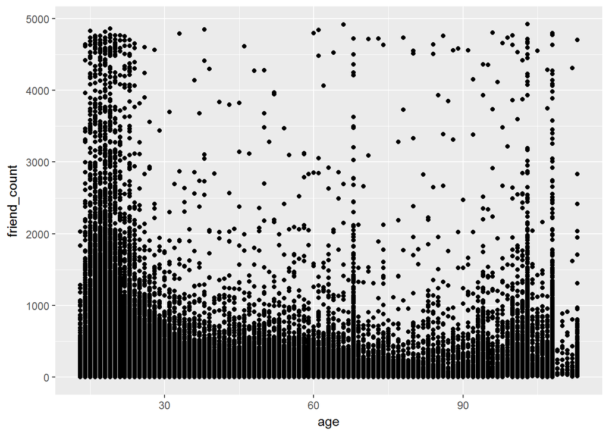

```r
# Using qplot
# qplot(x = age, y = friend_count, data = pf)

# qplot can also be used for scatterplot without labelling x and y but just using position
# qplot(age, friend_count, data = pf)

# Using ggplot

ggplot(data = pf, aes(x = age, y = friend_count)) +
  geom_point()
```

#### What are some things that you notice right away?

Response: __ I noticed __ that at some age groups of around 20, 70 and 100 the friend counts of people are very high.

**Udacity** : Besides that some accountsmay be fake due to ridiculous higher counts.

### ggplot Syntax

Notes:

Finding out the upper and lower limit of age using the summary() command.

```r
summary(pf$age)
```

```
##    Min. 1st Qu.  Median    Mean 3rd Qu.    Max.
##   13.00   20.00   28.00   37.28   50.00  113.00
```

__ In ggplot always add moifications as layers as this helps in debugging errors.__

Adding a layer to the ggplot code above to limit the x-axis from 13 to 90. As facebook users must have a minimum age of 13 and assume people above age of 90 given is false data.

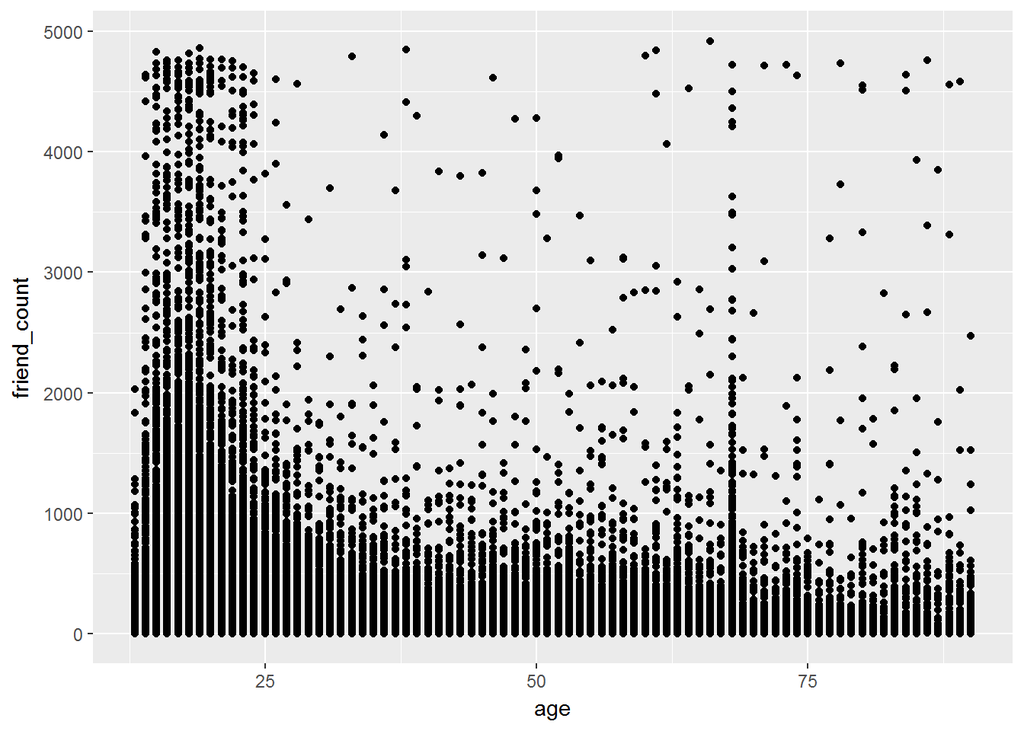

```r
ggplot(data = pf, aes(x = age, y = friend_count)) +
  geom_point() +
  xlim(13,90)
```

### Overplotting

Notes:

Overplotting makes it difficult to tell how many points are in each region. (Like in the graph these points are stacked one over the other).

We can **set the transparency of the points using the alpha parameter** in geom_points().

**(alpha = 1/20)** –> This makesit will take 20 points to be equivalent to one of these dark dot. That is 20 transparent points are required to make the dots dark.

**Alpha transparency for overlapping elements expressed as a fraction between 0 (complete transparency) and 1 (complete opacity).**

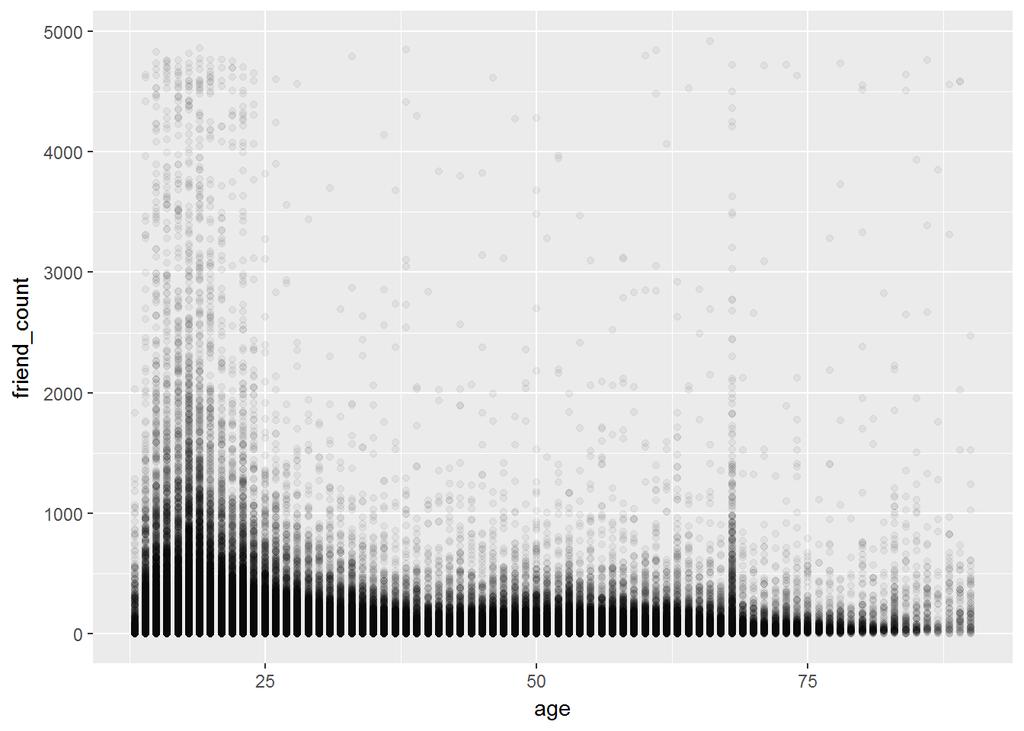

```r
ggplot(data = pf, aes(x = age, y = friend_count)) +
  geom_point(alpha = 1/20) +
  xlim(13,90)
```

Running the above code we see that bulk of our data lies between 1000.

We can also **add jitter**. In the code **swap geom_point() and geom_jitter().**

Age is a continuous variable and we have only integer values and we see above that the columns above are perfectly lined up columns which isn’t a true reflection of age (so its initutively wrong). We need to see more of points. Using jitter we add some noise to each age so that we get a clear pic of relationship between age and friend_count.

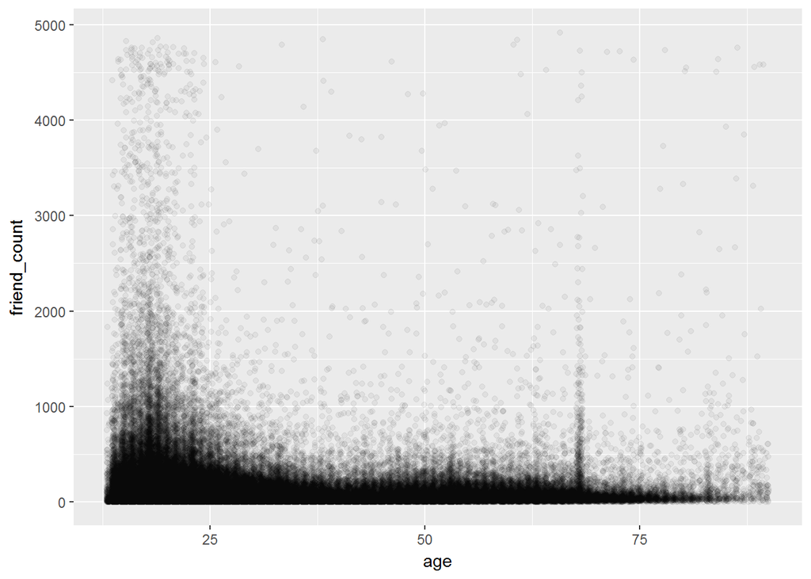

```r
ggplot(data = pf, aes(x = age, y = friend_count)) +
  geom_jitter(alpha = 1/20) +
  xlim(13,90)
```

Running our code with jitter we get a more dispersed distribution.

#### What do you notice in the plot?

Response:

### Coord_trans()

[Look up the documentation for coord_trans()](http://docs.ggplot2.org/current/coord_trans.html)

‘coord_trans’ is different to scale transformations in that it occurs after statistical transformation and will affect the visual appearance of geoms - there is no guarantee that straight lines will continue to be straight.

Transformations only work with continuous values.

x, y – transformers for x and y axes

limx, limy – limits for x and y axes. (Named so for backward compatibility)

Also refer : [geom_smooth()](http://ggplot2.tidyverse.org/reference/geom_smooth.html)

Add a **layer** to the plot that transforms friend_count using the square_root function.

Also switch back to **geom_point()** from **geom_jitter()**. As it is showing error when used with geom_jitter(). If we wanted to add **geom_jitter()** to the code we had to put more elaborate syntaxes to specify that we only wanted to jitter the ages. We have to be careful because if we add jitter to friend_count hten those people having zero(0) friend_count may have negative value for the friend_count.

And these may lead to square root resulting in imaginary values *i*. So to make this adjustment we pass the position parameter as ‘position = position_jitter(h = 0)’ where h is the minimum height. Hence it prevents us from getting the warnings and -ve error counts.

**Remember jitter can add +ve or -ve noise to each of our points.**

#### Look up the documentation for coord_trans() and add a layer to the plot that transforms friend_count using the square root function. Create your plot!

```
## Warning: Removed 5174 rows containing missing values (geom_point).
```

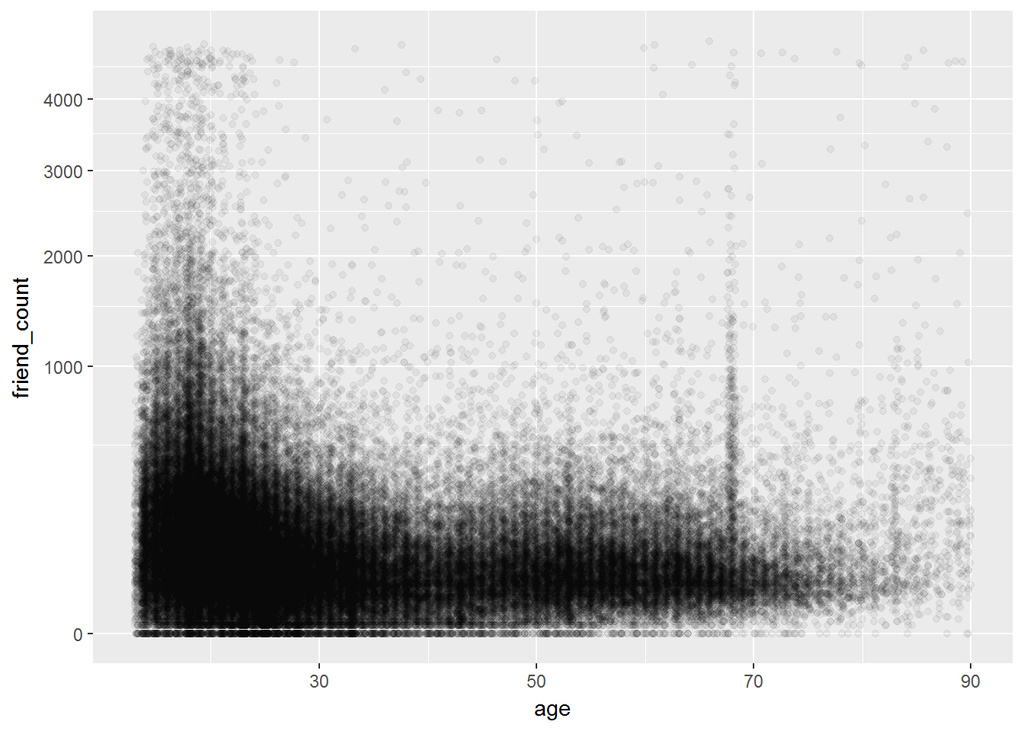

```r
ggplot(data = pf, aes(x = age, y = friend_count)) +
  geom_point(alpha = 1/20, position = position_jitter(h = 0)) +
  xlim(13,90)+
  coord_trans(y = 'sqrt')
```

Here we see distribution of friend_count conditional on age. For exaple we can see thresholds of friend_count above which there are many few users.

### Alpha and Jitter

Examine the relationship between friendships_initiated (y) and age (x) using the ggplot syntax. We recommend creating a basic scatter plot first to see what the distribution looks like and then adjusting it by adding one layer at a time.

Remember to make adjustments to the breaks of the x-axis and to use apply alpha and jitter.

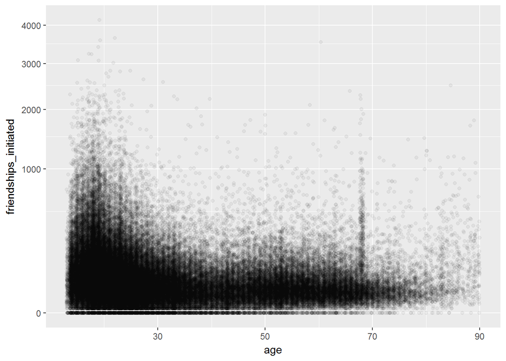

```r
ggplot(data = pf, aes(x = age, y = friendships_initiated)) +
  geom_point(alpha = 1/20, size = 1.5, position = position_jitter(h = 0))+
  xlim(13,90) +
  coord_trans(y = 'sqrt')
```

## Using coord_trans(‘log10’)

When I tried to submit the same graph using log10 in the coord_trans function, I got an error. My submission looked like this:

```
ggplot(aes(x = age, y = friendships_initiated), data = pf) + geom_point(alpha = 1/20, position = position_jitter(h = 1)) +
  xlim(13,90) +
  coord_trans(y = "log10")
```

log10 would throw an error if it was 0. some ‘friendships_initiated’ are zero. So used ‘y = friendships_initiated + 0.001’ ta avoid error using ‘log 0’.

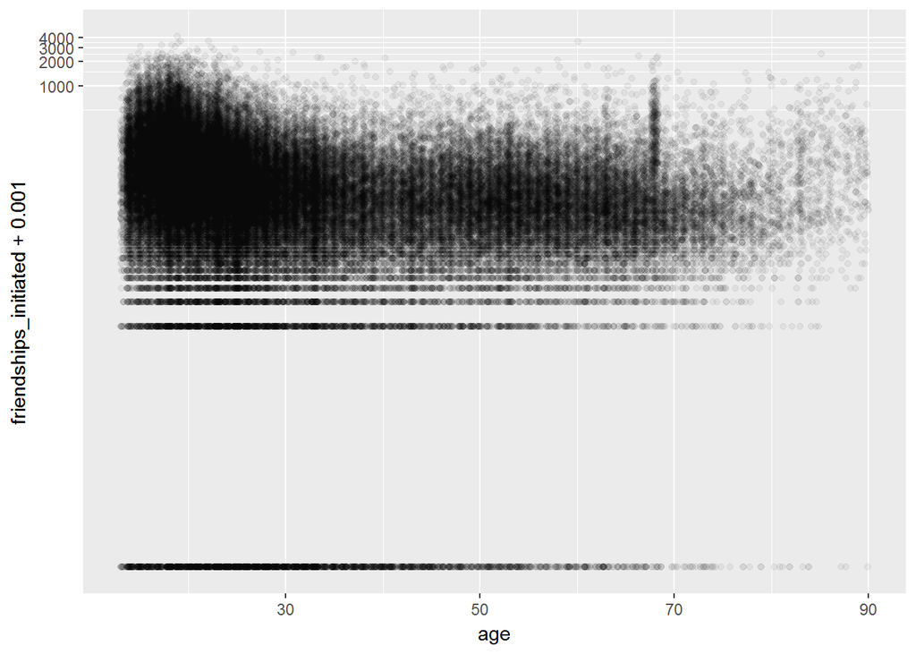

```r
ggplot(data = pf, aes(x = age, y = friendships_initiated + 0.001)) +
  geom_point(alpha = 1/20, size = 1.5, position = position_jitter(h = 0))+
  xlim(13,90) +
  coord_trans(y = 'log10')
```

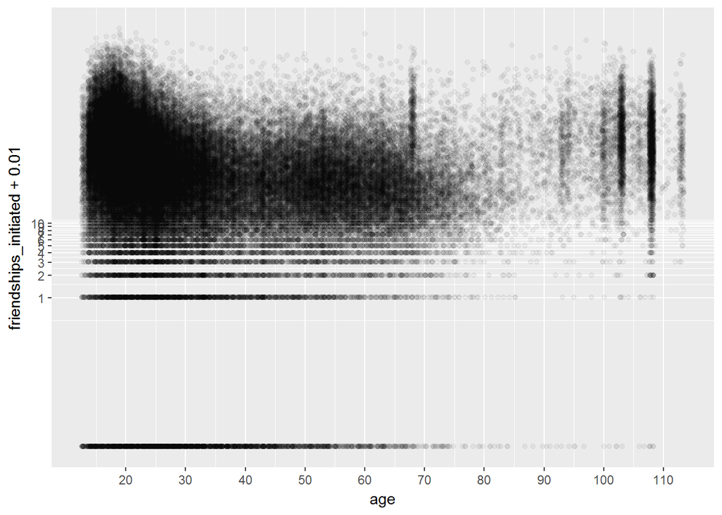

```r
ggplot(aes(x = age, y = friendships_initiated+0.01), data = pf) +
geom_point(alpha = 1/20, position = position_jitter(h=0)) +
coord_trans(y = "log10") +
scale_x_continuous(breaks = seq(0,max(pf$age),10))+
  scale_y_continuous(breaks = seq(0,10,1))
```

If you add breaks to the ‘y’ axis, you will see why there are bars of data in certain locations: This is because there is no jitter in the y direction and the values are integers.

### Conditional Means

Notes:

**dplyr** - package that helps to transform tidy, tabular data: Most common functions are: - filter() - groupby() - mutate() - arrange()

```r
age_groups <- group_by(pf,age)
pf.fc_by_age <- summarise(age_groups,
                          friend_count_mean = mean(friend_count),
                          friend_count_median = median(friend_count),
                          n = n()
                          )
pf.fc_by_age <- arrange(pf.fc_by_age, age)
head(pf.fc_by_age)
```

```
## # A tibble: 6 x 4
##     age friend_count_mean friend_count_median     n
##   <int>             <dbl>               <dbl> <int>
## 1    13          164.7500                74.0   484
## 2    14          251.3901               132.0  1925
## 3    15          347.6921               161.0  2618
## 4    16          351.9371               171.5  3086
## 5    17          350.3006               156.0  3283
## 6    18          331.1663               162.0  5196
```

### Conditional means alternate code using %%

```r
pf.fc_by_age2 <- pf %>%
  group_by(age) %>%
  summarise(friend_count_mean2 = mean(friend_count),
            friend_count_median2 = median(friend_count),
            n = n()) %>%
  arrange(age)

head(pf.fc_by_age2)
```

```
## # A tibble: 6 x 4
##     age friend_count_mean2 friend_count_median2     n
##   <int>              <dbl>                <dbl> <int>
## 1    13           164.7500                 74.0   484
## 2    14           251.3901                132.0  1925
## 3    15           347.6921                161.0  2618
## 4    16           351.9371                171.5  3086
## 5    17           350.3006                156.0  3283
## 6    18           331.1663                162.0  5196
```

Create your plot!

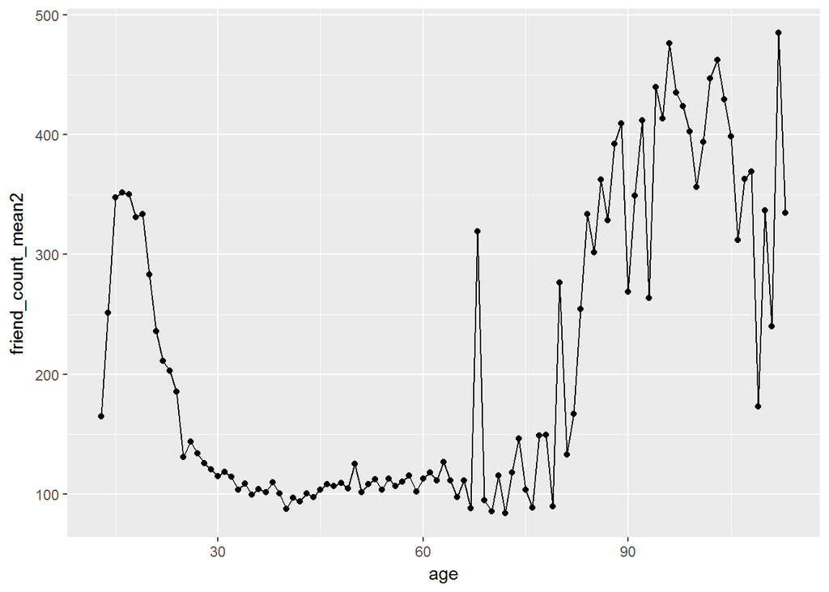

```r
ggplot(data = pf.fc_by_age2, aes(x = age, y = friend_count_mean2)) +
  geom_point()+
  geom_line()
```

### Overlaying Summaries with Raw Data

Notes: Ggplot allows us to easily create various summaries of our data and plot them. This could be especially useful for quick exploration and for combining plots of raw data, like our original scatter plot with displaying summaries.

This plot is one of those displaying summaries and I want to be able to display it over the original plot we had for friend_count versus age.

Let’s see that first original scatter plot again. Now since all these points are black, I’m going to change the color of these. So that way when I overlay the summary, it’s easier to see.

I’m going to make the color here orange. So now, I’ve got my scatter plot and I want to overlay the summary that we have from before. I want to put this on top of this. I can add a geom_line to our plot to do so. Here I’m **going to pass the parameter stat and set it equal to summary**, and I’m going to **give it a function for y**.

**The fun.y parameter takes any type of function, so that way we can apply it to the y values**. In this case, I want to take the mean.

And there it is, this is my summary line for the mean friend count by age, over my raw data or my scatter plot.

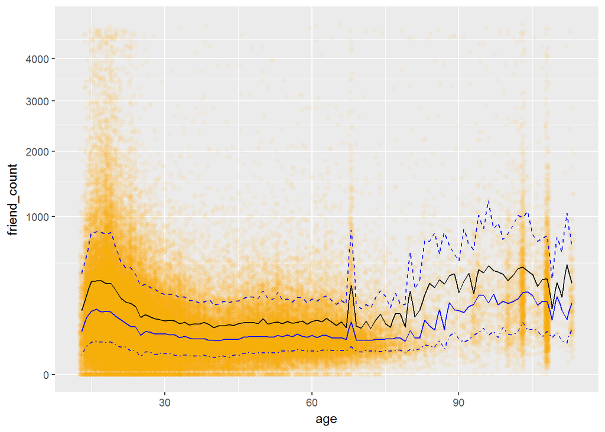

```r
ggplot(data = pf, aes(x = age, y = friend_count)) +
  geom_point(alpha = 1/20, position = position_jitter(h = 0), color = 'orange') +
  coord_cartesian(xlim = c(13,90))+
  coord_trans(y = 'sqrt')+
  geom_line(stat = 'summary', fun.y = mean) +
  geom_line(stat = 'summary', fun.y = quantile, fun.args = list(probs = 0.9), color = 'blue', linetype = 2 ) +
  geom_line(stat = 'summary', fun.y = quantile, fun.args = list(probs = 0.2), color = 'blue', linetype = 'dotdash' ) +
  geom_line(stat = 'summary', fun.y = quantile, fun.args = list(probs = 0.5), color = 'blue', linetype = 'solid' )
```

#### What are some of your observations of the plot?

Response: Having more than 1000 users is very rare even for very young users.

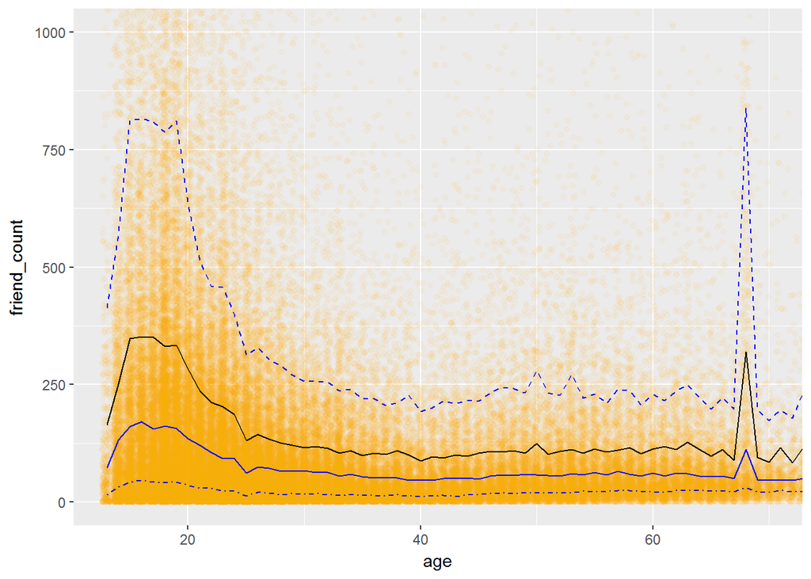

```r
ggplot(data = pf, aes(x = age, y = friend_count)) +
  geom_point(alpha = 1/20, position = position_jitter(h = 0), color = 'orange') +
  coord_cartesian(xlim = c(13,70), ylim = c(0,1000) )+
  geom_line(stat = 'summary', fun.y = mean) +
  geom_line(stat = 'summary', fun.y = quantile, fun.args = list(probs = 0.9), color = 'blue', linetype = 2 ) +
  geom_line(stat = 'summary', fun.y = quantile, fun.args = list(probs = 0.2), color = 'blue', linetype = 'dotdash' ) +
  geom_line(stat = 'summary', fun.y = quantile, fun.args = list(probs = 0.5), color = 'blue', linetype = 'solid' )
```

### Correlation

Notes:

```r
cor(pf$age, pf$friend_count)
```

```
## [1] -0.02740737
```

Look up the documentation for the cor.test function.

```r
cor.test(pf$age, pf$friend_count, method = 'pearson')
```

```
##
##  Pearson's product-moment correlation
##
## data:  pf$age and pf$friend_count
## t = -8.6268, df = 99001, p-value < 2.2e-16
## alternative hypothesis: true correlation is not equal to 0
## 95 percent confidence interval:
##  -0.03363072 -0.02118189
## sample estimates:
##         cor
## -0.02740737
```

Using **with()**:

```r
with( pf, cor.test(age, friend_count, method = 'pearson'))
```

```
##
##  Pearson's product-moment correlation
##
## data:  age and friend_count
## t = -8.6268, df = 99001, p-value < 2.2e-16
## alternative hypothesis: true correlation is not equal to 0
## 95 percent confidence interval:
##  -0.03363072 -0.02118189
## sample estimates:
##         cor
## -0.02740737
```

### Correlation on Subsets

Notes:

```r
with( subset(pf, (age >= 13)&(age<=70) ) , cor.test(age, friend_count, method = 'pearson'))
```

```
##
##  Pearson's product-moment correlation
##
## data:  age and friend_count
## t = -52.592, df = 91029, p-value < 2.2e-16
## alternative hypothesis: true correlation is not equal to 0
## 95 percent confidence interval:
##  -0.1780220 -0.1654129
## sample estimates:
##        cor
## -0.1717245
```

### Correlation Methods

Notes:

```r
with( pf, cor.test(age, friend_count, method = 'spearman'))
```

```
##
##  Spearman's rank correlation rho
##
## data:  age and friend_count
## S = 1.8801e+14, p-value < 2.2e-16
## alternative hypothesis: true rho is not equal to 0
## sample estimates:
##        rho
## -0.1624741
```

## Create Scatterplots

Notes: To see like received by users on desktop version of site. “likes_received” vs “www_likes_received”

```r
summary(pf$www_likes_received)
```

```
##      Min.   1st Qu.    Median      Mean   3rd Qu.      Max.
##      0.00      0.00      2.00     58.57     20.00 129953.00
```

```r
summary(pf$likes_received)
```

```
##     Min.  1st Qu.   Median     Mean  3rd Qu.     Max.
##      0.0      1.0      8.0    142.7     59.0 261197.0
```

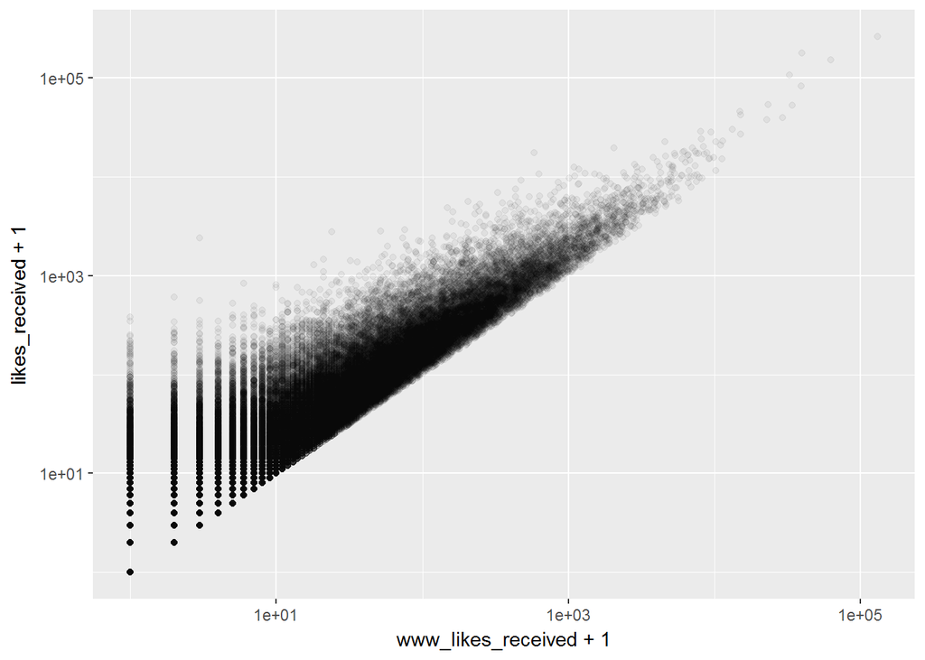

```r
ggplot(data = pf, aes(y = likes_received + 1, x = www_likes_received + 1))+
  geom_point(alpha = 1/20)+
  scale_x_log10()+
  scale_y_log10()
```

### Strong Correlations

Notes: Looking at this plot, we can see that we have some funky outliers in here. And down here is the bulk of our data.

To determine good x and y limits for our axis, we can look at 95th percentile, using the quantile command. This will let us see the 95th percentile of www_likes_received. And the 95th percentile of likes received. And hopefully, we should get rid of some of these points.

To do that, use the x lim layer and the y lim layer. We’ll pass zero as the lower bound for xlim, and for the upper limit, we’ll use the ninety-fifth percent quantile for the www likes received. Similarly, for likes received, we’ll use the same sort of syntax and just replace the variable. Zero will be our lower bound, and the ninety fifth percentile for likes received will be our upper bound.

When I run this code, we’re in effect zooming in on that lower portion of the graph that we had over here. The slope of the line of best fit through these points is the correlation.

And, we can even add to the plot by using **geom_smooth()** code. We do that by adding a smoother, and setting the method to a linear model or lm. Notice too that I also colored it red so that we could see it through the black points. Let’s quantify this relationship with a number

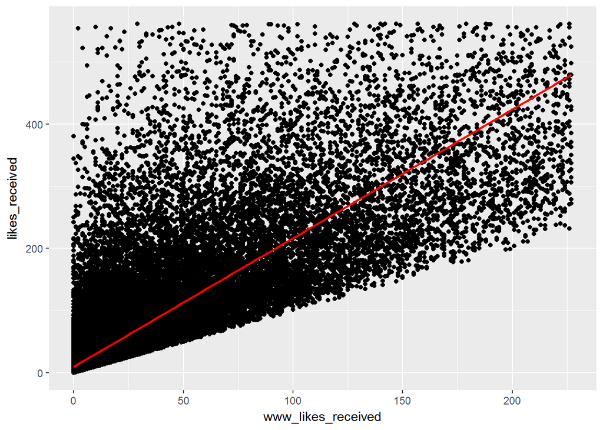

```r
ggplot(data = pf, aes(x = www_likes_received, y = likes_received))+
  geom_point()+
  xlim(0, quantile(pf$www_likes_received, .95))+
  ylim(0, quantile(pf$likes_received, 0.95)) +
  geom_smooth(method = 'lm', color = 'red')
```

What’s the correlation betwen the two variables? Include the top 5% of values for the variable in the calculation and round to 3 decimal places.

```r
with(pf, cor.test(www_likes_received, likes_received))
```

```
##
##  Pearson's product-moment correlation
##
## data:  www_likes_received and likes_received
## t = 937.1, df = 99001, p-value < 2.2e-16
## alternative hypothesis: true correlation is not equal to 0
## 95 percent confidence interval:
##  0.9473553 0.9486176
## sample estimates:
##       cor
## 0.9479902
```

Response:0.948

The correlation that we just found was an artifact of the nature of the variables. One of them was really a superset of the other. So such high value.

The correlation coefficient is invariant under a linear transformation of either X or Y, and the slope of the regression line when both X and Y have been transformed to z-scores is the correlation coefficient.

It’s important to note that we may not always be interested in the bulk of the data. Sometimes, the outliers ARE of interest, and it’s important that we understand their values and why they appear in the data set.

### Moira on Correlation

__Notes:__ Strong correlations might not always be a good thing.

So in addition to doing scatter plots where you can visually see how related two variables are typically, measure their correlation coefficient to really quantify how correlated they are. This is really important, because a lot of the data that I work with is correlated with each other.

And so typically, when I’m working on a problem and I’m going to be doing some kind of regression where I’m modeling something, I’m going to be throwing some of these variables into the regression. And one of the assumptions of regression is these variables are independent of each other. And so if any two are too highly correlated with each other, it will be really difficult to tell which ones are actually driving the phenomenon. And so it’s important to measure the correlation between your variables first, often because it’ll help you determine which ones you don’t actually want to throw in together, and it might help you decide which ones you actually want to keep. ***

### More Caution with Correlation

Notes: As Moire put it out, correlation can help us decide which variables are related. But even correlation coefficients can be deceptive if you’re not careful. Plotting your data is the best way to help you understand it and it can lead you to key insights. Let’s consider another data set that comes with the alr3 package.

You’ll need to install this package first and then make sure you load it. The data set that we’re going to load is called the Mitchell Data Set. The Mitchell Data Set contains soil temperatures from Mitchell, Nebraska.By working with this data set, we’ll see how correlation can be somewhat deceptive. So, for your first task, I want you **to create a scatter plot of temperature versus months.**

```r
# install.packages('alr3')
suppressMessages(library(alr3))

data("Mitchell")
summary(Mitchell)
```

```
##      Month             Temp
##  Min.   :  0.00   Min.   :-7.4778
##  1st Qu.: 50.75   1st Qu.:-0.3486
##  Median :101.50   Median :10.4500
##  Mean   :101.50   Mean   :10.3125
##  3rd Qu.:152.25   3rd Qu.:20.4306
##  Max.   :203.00   Max.   :27.6056
```

```r
head(Mitchell)
```

```
##   Month     Temp
## 1     0 -5.18333
## 2     1 -1.65000
## 3     2  2.49444
## 4     3 10.40000
## 5     4 14.99440
## 6     5 21.71670
```

#### Working with this dataset we se how correlation can be deceptive

Create your plot!

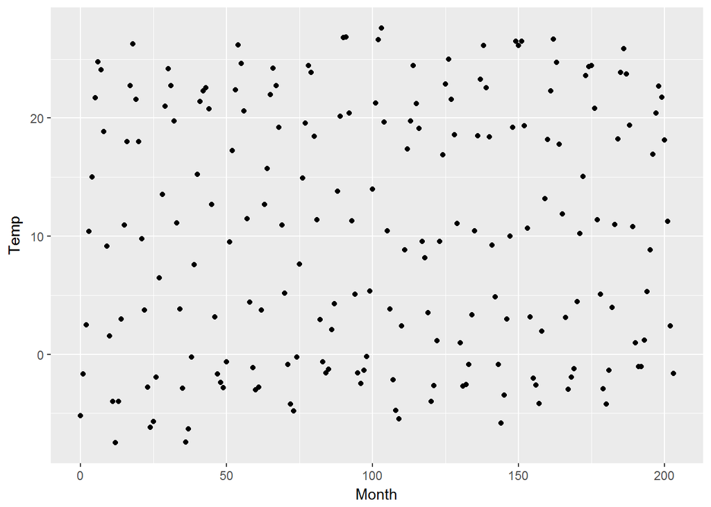

```r
ggplot(data = Mitchell, aes(x = Month, y = Temp)) +
  geom_point()
```

### Noisy Scatterplots

1. Take a guess for the correlation coefficient for the scatterplot. Ans : 0
2. What is the actual correlation of the two variables? (Round to the thousandths place or 3rd decimal place) Ans : 0.057

```r
cor.test( Mitchell$Month, Mitchell$Temp, method = 'pearson' )
```

```
##
##  Pearson's product-moment correlation
##
## data:  Mitchell$Month and Mitchell$Temp
## t = 0.81816, df = 202, p-value = 0.4142
## alternative hypothesis: true correlation is not equal to 0
## 95 percent confidence interval:
##  -0.08053637  0.19331562
## sample estimates:
##        cor
## 0.05747063
```

### Making Sense of Data

Notes: While there might not appear to be a correlation between the two variables, let’s think about this a little bit more. What’s on the x-axis? Months. And what’s on the y-axis? Temperature. So, we know that this month variable is very discreet. We’ll have the months from January to December, and they’ll repeat over and over again. Let’s be sure we add that detail to our plot. Here’s the code that we used to create the plot using the ggplot syntax. What layer and syntax would you add to this plot in order to make that change? Type in your code here. You’ll want to break open the x-axis every 12 months, so that way it corresponds to a year. I’ll let you figure out what the lower and upper limits of the x axis should be. So, what do you think? What layer and syntax should we add?

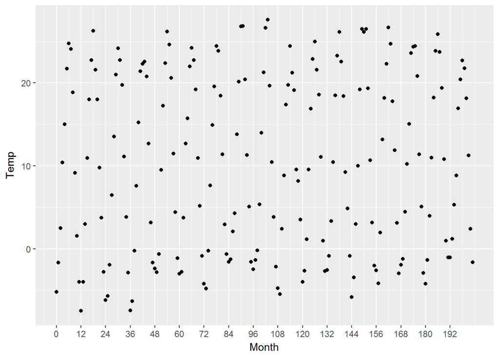

```r
ggplot(data = Mitchell, aes(x = Month, y = Temp)) +
  geom_point() +
  scale_x_continuous(breaks = seq(0,203,12))
```

### A New Perspective

Now we’ve got a plot here, and I want you to take a new perspective on it. Take your plot and stretch it out horizontally as much as you can in r. Make the horizontal axis be longer than the vertical axis.

What do you notice? Response: When I stretch out of the graph, I notice that I get more of a cyclical pattern. It’s almost like a sine or a cosine graph. And this makes sense with what the story the data’s telling. I mean, there are seasons in Nebraska, so we should see fluctuation in the temperature every 12 months.

This is one example of how it’s so important to get perspective on your data. You want to make sure you put your data in context. Another important point to make here is that the **proportion and scale of your graphics do matter.** Pioneers in the field of data visualization such as Playfair and Tukey studied this extensively. They determined that the **nature of the data should suggest the shape of the graphic. Otherwise, you should tend to have a graphic that’s about 50% wider than it is tall.**

You could also get perspective on this data by **overlaying each year’s data on top of each other**, giving a clear, generally sinusoidal graph. You can **do this by using the R’s modulus operator %% in your code.**

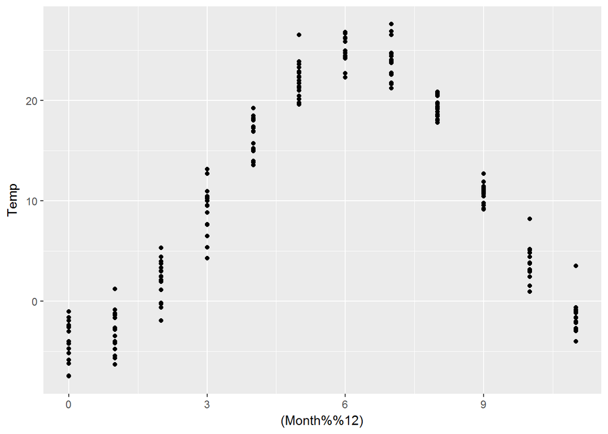

```r
ggplot(aes(x=(Month%%12),y=Temp), data=Mitchell)+
  geom_point()
```

### Understanding Noise: Age to Age Months

Notes: Let’s return to our scatter plot that summarized the relationship between age and mean friend count. Recall that we ended up creating this plot from the new data frame that we created using the dplyr package. The plot looked like this.

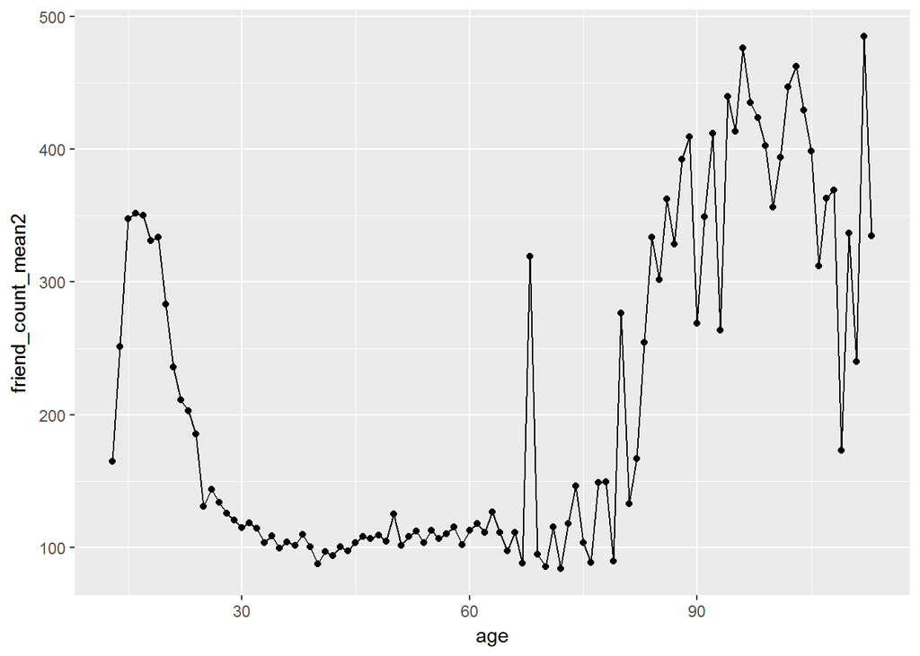

```r
ggplot(data = pf.fc_by_age2, aes(x = age, y = friend_count_mean2)) +
  geom_point()+
  geom_line()
```

As you can see, the black line has a lot of random noise to it. That is, the mean friend count rises and falls over each age. Let’s print out some of our data frame to have a closer look.

```r
head(pf.fc_by_age2,10)
```

```
## # A tibble: 10 x 4
##      age friend_count_mean2 friend_count_median2     n
##    <int>              <dbl>                <dbl> <int>
##  1    13           164.7500                 74.0   484
##  2    14           251.3901                132.0  1925
##  3    15           347.6921                161.0  2618
##  4    16           351.9371                171.5  3086
##  5    17           350.3006                156.0  3283
##  6    18           331.1663                162.0  5196
##  7    19           333.6921                157.0  4391
##  8    20           283.4991                135.0  3769
##  9    21           235.9412                121.0  3671
## 10    22           211.3948                106.0  3032
```

As we can see, the mean friend count increases, then decreases later.

```r
pf.fc_by_age2[17:19, ]
```

```
## # A tibble: 3 x 4
##     age friend_count_mean2 friend_count_median2     n
##   <int>              <dbl>                <dbl> <int>
## 1    29           120.8182                 66.0  1936
## 2    30           115.2080                 67.5  1716
## 3    31           118.4599                 63.0  1694
```

In one particular case, we can see that for 30 year olds, the mean friend count is actually lower compared to the 29 year olds and the sense, such as the spike at age 69. But others are likely just to be noise around the true smoother relationship between age and friend count. That is, they reflect that we just have a sample from the data generating process. And so the estimated mean friend count for each age is the true mean plus some noise.

We can imagine that the **noise for this plot would be worse if we chose finer bins for age.** For example, we could **estimate conditional means for each age, measured in months instead of years.**

Over the next few programming exercises, you’re going to do just that. You’re going to create a plot just like this one with a new variable that measures ages in months instead of years.

Then you’ll plot the conditional mean for ages in months, and we’ll compare this graph to the one that you create. To start, you’re going to create the age with months variable, and save it into the data frame. This variable will have each user’s age measured in months rather than in years. So, if a user is 36 years old and was born in March, the user’s age would be 36.75.

### Age with Months Means

```r
pf$age_with_months <- with(pf, age + (1- dob_month/12))
```

Programming Assignment :

We’re on our way to plotting the conditional means for a to months. Remember we’re trying to generate this plot again but only for smaller bin widths. We’ll have more data points since age will be measured in months rather than in years. Now that we’ve got our age with months variable from before we can go ahead and use the d apply r functions.

To get a new data frame with an average friend count. And the median friend count for each age with months. So here comes your second programming task. **Create a new data frame called pf.fc_by_age_months that contains the mean friend count, the median friend count, and the number of users in each group of age with months.**

Please note that in newer versions of dplyr (0.3.x+), the syntax %.% has been deprecated and replaced with %>%. Videos in the course use %.%, which will produce warning messages. If you answer using the chain operator, you should use %>% instead.

Another warning: Version 0.4.0 of dplyr has a bug when using the median function on the summarize layer, depending on the nature of the data being summarized. You may need to cast the data as a numeric (float) type to get the expected results, e.g. median(as.numeric(var)).

A few additional hints follow below:

Hint 1: Use the group_by(), summarise(), and arrange() functions in the dplyr package to split the data frame by age_with_month. Make sure you arrange by the correct variable (it’s not age anymore).

Hint 2: The code should look similar to the code when we split the data frame by age and found summaries:

```
age_groups <- group_by(pf, age)
pf.fc_by_age <- summarise(age_groups,
                          friend_count_mean = mean(friend_count),
                          friend_count_median = median(friend_count),
                          n = n())
pf.fc_by_age <- arrange(pf.fc_by_age, age)
head(pf.fc_by_age)
```

```r
pf.fc_by_age_months <- pf %>%
  group_by(age_with_months) %>%
  summarise(frnd_count_mean = mean(friend_count),
            frnd_count_median = median(friend_count),
            n = n()) %>%
  arrange(age_with_months)
```

```r
head(pf.fc_by_age_months)
```

```
## # A tibble: 6 x 4
##   age_with_months frnd_count_mean frnd_count_median     n
##             <dbl>           <dbl>             <dbl> <int>
## 1        13.16667        46.33333              30.5     6
## 2        13.25000       115.07143              23.5    14
## 3        13.33333       136.20000              44.0    25
## 4        13.41667       164.24242              72.0    33
## 5        13.50000       131.17778              66.0    45
## 6        13.58333       156.81481              64.0    54
```

### Noise in Conditional Means

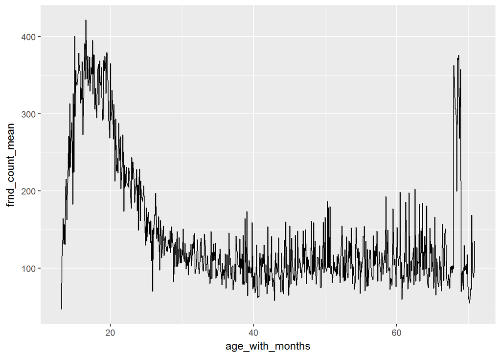

```r
ggplot(data = subset(pf.fc_by_age_months, age_with_months<71),aes(x=age_with_months, y=frnd_count_mean))+
  geom_line()
```

### Smoothing Conditional Means

Notes:

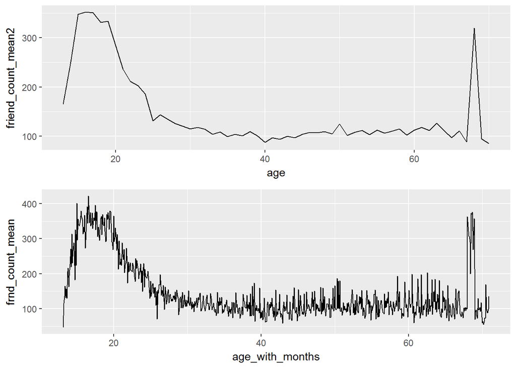

```r
p1 <- ggplot(data = subset(pf.fc_by_age2, age<71), aes(x = age, y = friend_count_mean2)) +
  geom_line()


p2 <- ggplot(data = subset(pf.fc_by_age_months, age_with_months<71),aes(x=age_with_months, y=frnd_count_mean))+
  geom_line()

suppressMessages(library(gridExtra))
grid.arrange(p1,p2,ncol=1)
```

**By decreasing the size of our bins and increasing the number of bins, we have less data to estimate each conditional mean. We can see that the noise is a lot worse on this graph since we have finer bin choices.** On the other hand, we could go the other direction and increase the size of the bins.

On the other hand, we could go the other direction and **increase the size of the bins. Say, we could lump everyone together whose age falls under a multiple of five. Essentially what we’ll do is, we’ll cut our graph in pieces and average these mean friend counts together.**

So, users who are within two and a half years of 40 will get lumped into one point. The same will be true for users who are within two and a half years of 50 and for users who are in two and a half years of 60. I’ll show you what I mean in code. Here, I’m creating a plot with age that’s been divided by five, rounded and then multiplied by five. I’ve also subsetted our data frame, just like the other plots. The last thing I’ll do is I’ll add a geom line with a stat summary. I don’t really want to plot the friend count, I want to plot the mean friend count.

Here, I’m creating a plot with age that’s been divided by five, rounded and then multiplied by five. I’ve also subsetted our data frame, just like the other plots. The last thing I’ll do is I’ll add a geom line with a stat summary. I don’t really want to plot the friend count, I want to plot the mean friend count. So I’ll pass summary to stat, and I’ll pass mean to fun.y.

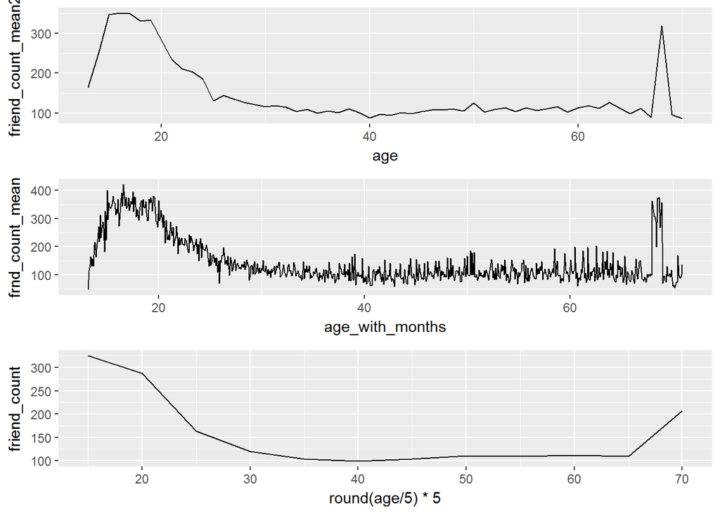

```r
p1 <- ggplot(data = subset(pf.fc_by_age2, age<71), aes(x = age, y = friend_count_mean2)) +
  geom_line()


p2 <- ggplot(data = subset(pf.fc_by_age_months, age_with_months<71),aes(x=age_with_months, y=frnd_count_mean))+
  geom_line()

p3 <- ggplot(data = subset(pf, age<71), aes(x=round(age/5)*5, y=friend_count ))+
  geom_line(stat = 'summary', fun.y = mean)


grid.arrange(p1,p2,p3,ncol=1)
```

see how we have less data points here. And wider bin widths. By doing this, we would estimate the mean more precisely, but potentially miss important features of the age and friend count relationship.

These three plots are an example of the **bias variance tradeoff**, and it’s **similar to the tradeoff we make when choosing the bin width in histograms**. One way that **analysts can better make this trade off is by using a flexible statistical model to smooth our estimates of conditional means**.

ggplot makes it easier fit such models using geom smooth. So, instead of seeing all this noise, we’ll have a smooth modular function that will fit along the data.

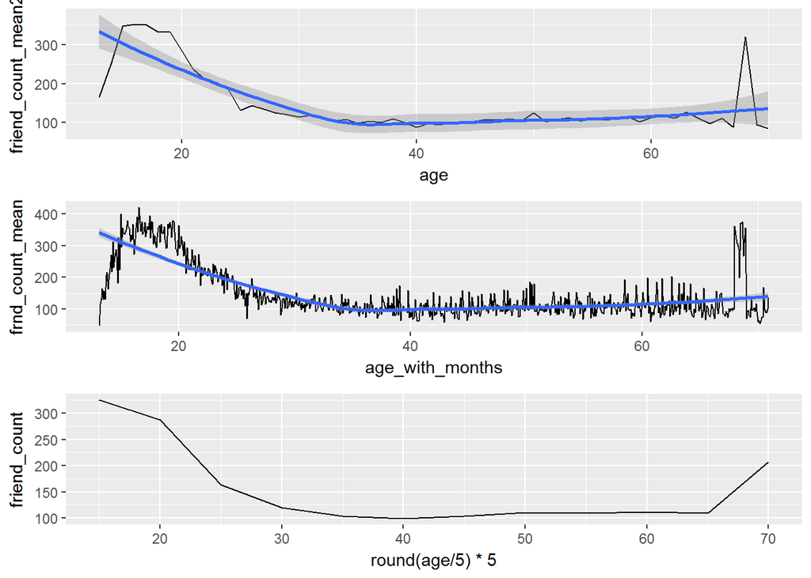

```r
p1 <- ggplot(data = subset(pf.fc_by_age2, age<71), aes(x = age, y = friend_count_mean2)) +
  geom_line() +
  geom_smooth()


p2 <- ggplot(data = subset(pf.fc_by_age_months, age_with_months<71),aes(x=age_with_months, y=frnd_count_mean))+
  geom_line() +
  geom_smooth()

p3 <- ggplot(data = subset(pf, age<71), aes(x=round(age/5)*5, y=friend_count ))+
  geom_line(stat = 'summary', fun.y = mean)


grid.arrange(p1,p2,p3,ncol=1)
```

added the geom smooth layer to both our first plot and our second plot. I’m just using ggplot’s defaults so all the decisions about what model we’ll be using will be made for us. If you’re interested in exploring the models and the parameters, take a look at the geom smooth documentation.

While the smoother captures some of the features of this relationship, it doesn’t draw attention to the non-monotonic relationship in the low ages well. Not only that, but it really misses the discontinuity at age 69. This highlights that using models like lowess or smoothing splines can be useful. But, like nearly any model, it can be subject to systematic errors, when the true process generating our data isn’t so consistent with the model itself. Here the models are based on the idea that true function is smooth. But, we really know that there’s some discontinuity in the relationship. ***

### Analyzing Two Variables

Reflection: In this lesson, we learned how to explore the relationship between two variables. Our main visualization tool, was the scatter plot. But we also augmented the scatter plot, with conditional summaries, like means.

We also learned about the benefits and the limitations of using correlation. To understand the relationship between two variables and how correlation may affect your decisions over which variables to include in your final models.

As usual, another important part of this lesson was learning how to make sense of data through adjusting our visualizations. We learned not to necessarily trust our interpretation of initial scatter plots like with the seasonal temperature data. And we learned how to use jitter and transparency to reduce over plotting.

Click **KnitHTML** to see all of your hard work and to have an html page of this lesson, your answers, and your notes!